# Ursus Americanus - Exploratory Data Analysis

### Load and inspect data

```r
# bear occurrences from GBIF
load("bc_bear_occurrences.Rda")
str(occ_data)
```

```
## tibble [4,878 × 153] (S3: tbl_df/tbl/data.frame)
##  $ key                                  : chr [1:4878] "5037007348" "5062960877" "5062976099" "5087169926" ...
##  $ scientificName                       : chr [1:4878] "Ursus americanus Pallas, 1780" "Ursus americanus Pallas, 1780" "Ursus americanus Pallas, 1780" "Ursus americanus Pallas, 1780" ...
##  $ decimalLatitude                      : num [1:4878] 48.9 50.4 50.4 49.1 49.8 ...
##  $ decimalLongitude                     : num [1:4878] -126 -121 -121 -125 -119 ...
##  $ issues                               : chr [1:4878] "cdc,cdround" "cdc,cdround" "cdc,cdround" "cdc,cdround" ...
##  $ datasetKey                           : chr [1:4878] "50c9509d-22c7-4a22-a47d-8c48425ef4a7" "50c9509d-22c7-4a22-a47d-8c48425ef4a7" "50c9509d-22c7-4a22-a47d-8c48425ef4a7" "50c9509d-22c7-4a22-a47d-8c48425ef4a7" ...
##  $ publishingOrgKey                     : chr [1:4878] "28eb1a3f-1c15-4a95-931a-4af90ecb574d" "28eb1a3f-1c15-4a95-931a-4af90ecb574d" "28eb1a3f-1c15-4a95-931a-4af90ecb574d" "28eb1a3f-1c15-4a95-931a-4af90ecb574d" ...
##  $ installationKey                      : chr [1:4878] "997448a8-f762-11e1-a439-00145eb45e9a" "997448a8-f762-11e1-a439-00145eb45e9a" "997448a8-f762-11e1-a439-00145eb45e9a" "997448a8-f762-11e1-a439-00145eb45e9a" ...
##  $ hostingOrganizationKey               : chr [1:4878] "28eb1a3f-1c15-4a95-931a-4af90ecb574d" "28eb1a3f-1c15-4a95-931a-4af90ecb574d" "28eb1a3f-1c15-4a95-931a-4af90ecb574d" "28eb1a3f-1c15-4a95-931a-4af90ecb574d" ...
##  $ publishingCountry                    : chr [1:4878] "CA" "CA" "CA" "CA" ...
##  $ protocol                             : chr [1:4878] "DWC_ARCHIVE" "DWC_ARCHIVE" "DWC_ARCHIVE" "DWC_ARCHIVE" ...
##  $ lastCrawled                          : chr [1:4878] "2025-04-02T15:54:54.054+00:00" "2025-04-02T15:54:54.054+00:00" "2025-04-02T15:54:54.054+00:00" "2025-04-02T15:54:54.054+00:00" ...
##  $ lastParsed                           : chr [1:4878] "2025-04-04T21:36:06.545+00:00" "2025-04-04T22:06:52.475+00:00" "2025-04-04T21:36:29.918+00:00" "2025-04-04T21:36:58.435+00:00" ...
##  $ crawlId                              : int [1:4878] 528 528 528 528 528 528 528 528 528 528 ...
```

[output cut: 86 more lines]

```r
# BC covariate data
load("BC_Covariates.Rda")
summary(DATA)
```

```
##            Length Class           Mode
## Window      1     SpatialPolygons S4
## Elevation  10     im              list
## Forest     10     im              list
## HFI        10     im              list
## Dist_Water 10     im              list
```

### Visualize bear occurrences in BC

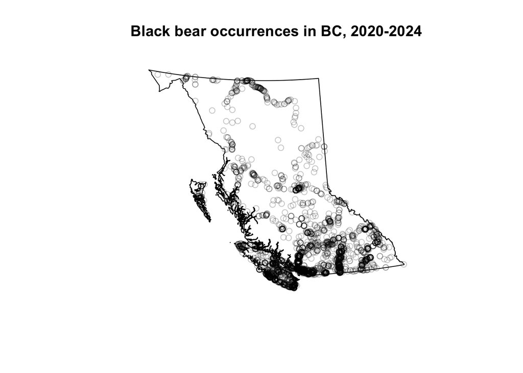

```r
# extract location columns
bears_loc <- occ_data[, c("decimalLongitude", "decimalLatitude", "month", "year")]
bears_loc_filtered <- subset(bears_loc, year %in% c(2020, 2021, 2022, 2023, 2024))

# create sf object
bears_sf <- st_as_sf(
  bears_loc_filtered,
  coords = c("decimalLongitude", "decimalLatitude"),
  crs = 4326  # WGS84 (longitude/latitude)
)

# BC Albers projection
bears_sf_proj <- st_transform(bears_sf, crs = 3005)

# extract BC window
window_sf <- st_as_sf(DATA$Window) # convert SpatialPolygons to Simple Features (sf)
window_proj <- st_transform(window_sf, crs = 3005) # ensure same CRS
window <- as.owin(window_proj) # convert to owin using sf object

# To avoid plotting points outside window (illegal points)
# Intersect points with window
bears_sf_proj <- subset(bears_sf_proj, st_within(bears_sf_proj, window_proj, sparse = FALSE))

# extract x, y coordinates
coords <- st_coordinates(bears_sf_proj)

# create ppp object
bears_ppp <- ppp(
  x = coords[,1],
  y = coords[,2],
  window = window
)
plot(bears_ppp, pch = 21, main = "Black bear occurrences in BC, 2020-2024")
```

Bear occurrences appear to be non-random, with clusters of high occurrence intensity found across the province. Intensity generally increases from North to South, with a particularly high concentration of observations in Southern Vancouver Island, suggesting localized hotspots of bear activity.

### Compare seasonal distributions (2020-2024)

```r
# Define the seasons by month number
seasons <- list(
  winter = c(12, 1, 2),
  spring = c(3, 4, 5),
  summer = c(6, 7, 8),
  autumn = c(9, 10, 11)
)

# Create an empty list to store the ppp objects for each season
ppp_list <- list()

# Create an empty list to store the filtered data for each season
bears_sf_list <- list()

# Loop over seasons
for (i in 1:length(seasons)) {

  # Filter for each season
  season_name <- names(seasons)[i]
  season_months <- seasons[[i]]

  # Filter bears_loc_filtered by the season's months
  bears_loc_season <- bears_loc_filtered[bears_loc_filtered$month %in% season_months, ]

  # Print the number of observations for this season
  cat(season_name, ": ", nrow(bears_loc_season), " observations\n", sep="")

  # Create sf object for the filtered season
  bears_sf_season <- st_as_sf(
    bears_loc_season,
    coords = c("decimalLongitude", "decimalLatitude"),
    crs = 4326  # WGS84 (longitude/latitude)
  )

  # Transform to BC Albers projection
  bears_sf_season_proj <- st_transform(bears_sf_season, crs = 3005)

  # Store sf object in the list
  bears_sf_list[[season_name]] <- bears_sf_season_proj

  # Extract x, y coordinates
  coords <- st_coordinates(bears_sf_season_proj)

  # Create ppp object for each season
  suppressWarnings(
    bears_ppp_season <- ppp(
      x = coords[, 1],
      y = coords[, 2],
      window = window
    )
  )

  # Store ppp object in the list
  ppp_list[[season_name]] <- bears_ppp_season
}
```

```
## winter: 76 observations
## spring: 808 observations
## summer: 1862 observations
## autumn: 841 observations
```

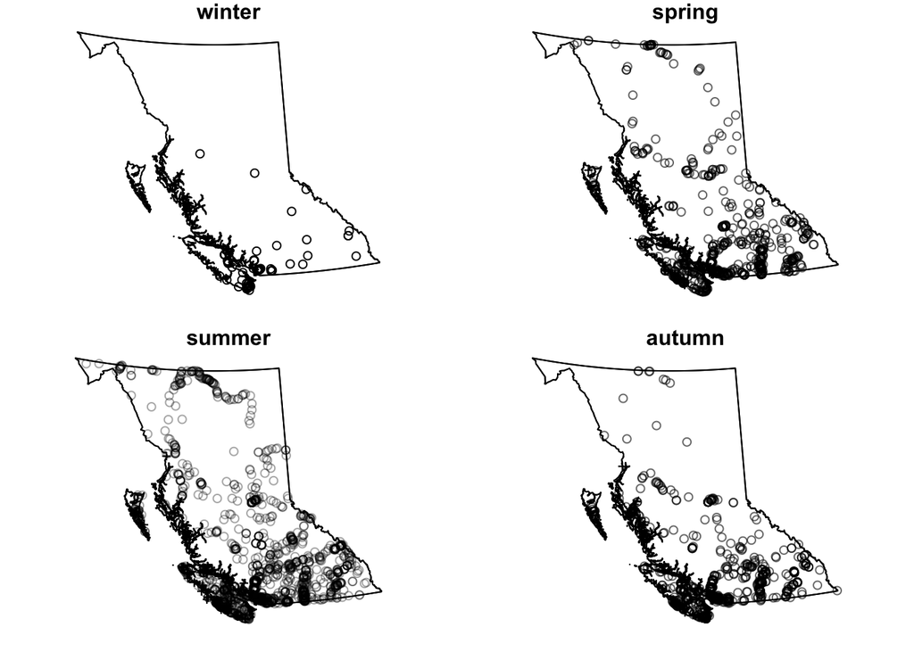

```r
# Plot the four maps in a 2x2 grid
par(mfrow=c(2,2), mar=c(1,1,1,1))  # Set up a 2x2 plotting window

# Loop over ppp objects and plot them
for (i in 1:length(ppp_list)) {
  season_name <- names(ppp_list)[i]
  suppressWarnings(
    plot(ppp_list[[season_name]], main = season_name, pch = 21)
  )
}
```

The occurrence patterns of bears seem to differ by season, mostly in terms of number of occurrences. Summer months have the most bear occurrences, followed by Autumn and Spring which are comparable, and Winter having very few occurrences, likely due to hibernation.

### KDE for each season

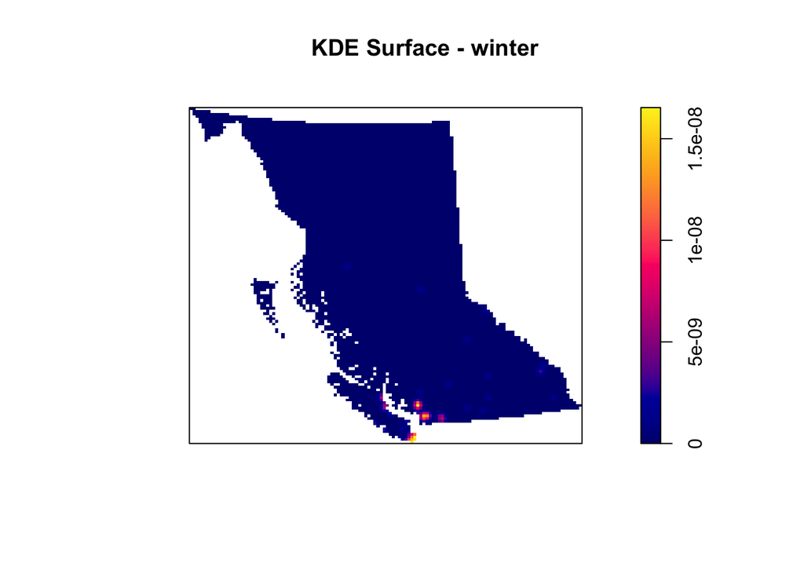

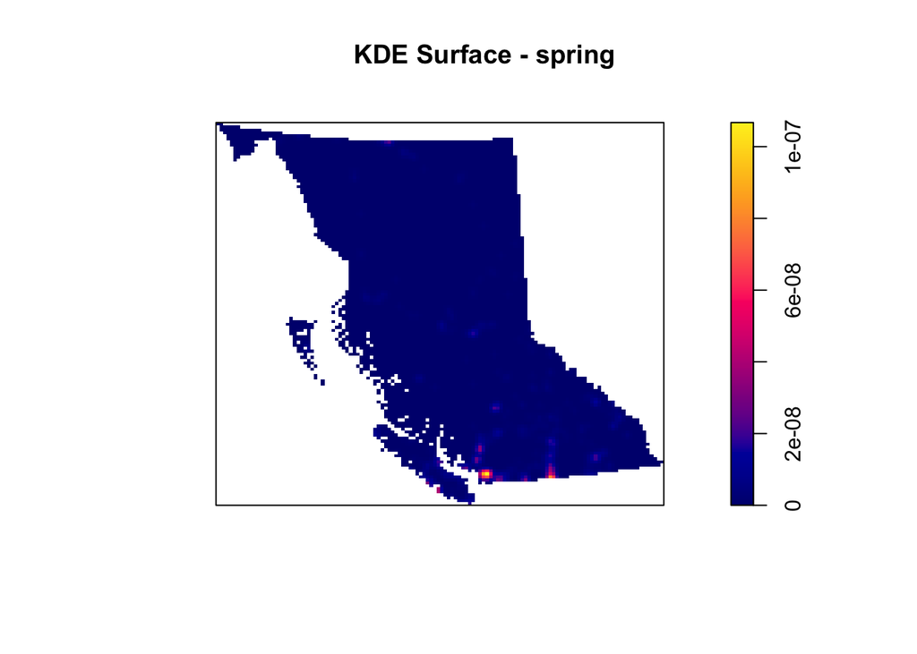

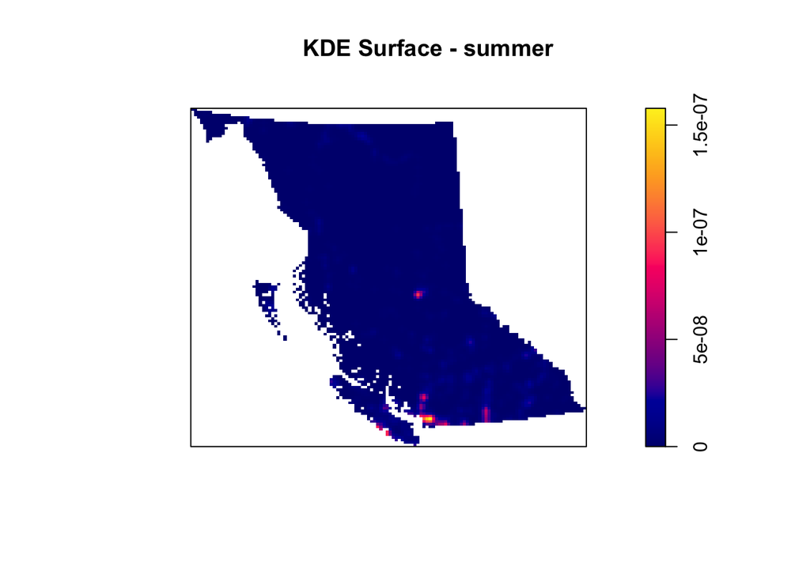

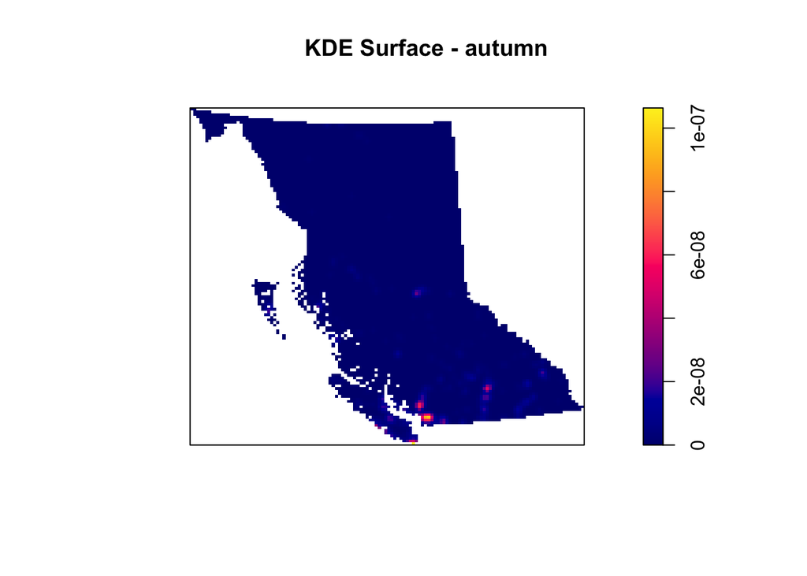

```r
# KDE comparison
dens_list <- lapply(ppp_list, function(p) density(p, sigma = 10000))
for (s in names(dens_list)) {
  plot(dens_list[[s]], main = paste("KDE Surface -", s))
}
```

### Performing Quadrat test for each season

Dividing area into a grid of 5x5 and testing for deviations from a random distribution.

```
##
##  Chi-squared test of CSR using quadrat counts
##
## data:  ppp_list[[s]]
## X2 = 561.39, df = 20, p-value < 2.2e-16
## alternative hypothesis: two.sided
##
## Quadrats: 21 tiles (irregular windows)
```

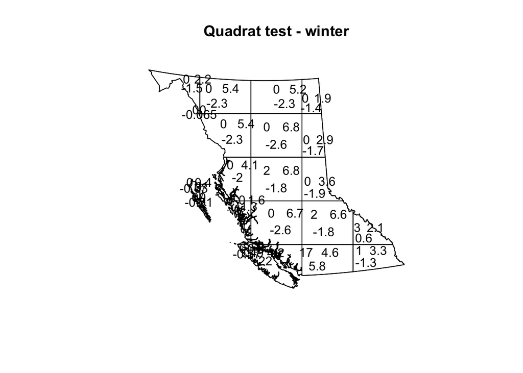

```
##
##  Chi-squared test of CSR using quadrat counts
##
## data:  ppp_list[[s]]
## X2 = 2202.7, df = 20, p-value < 2.2e-16
## alternative hypothesis: two.sided
##
## Quadrats: 21 tiles (irregular windows)
```

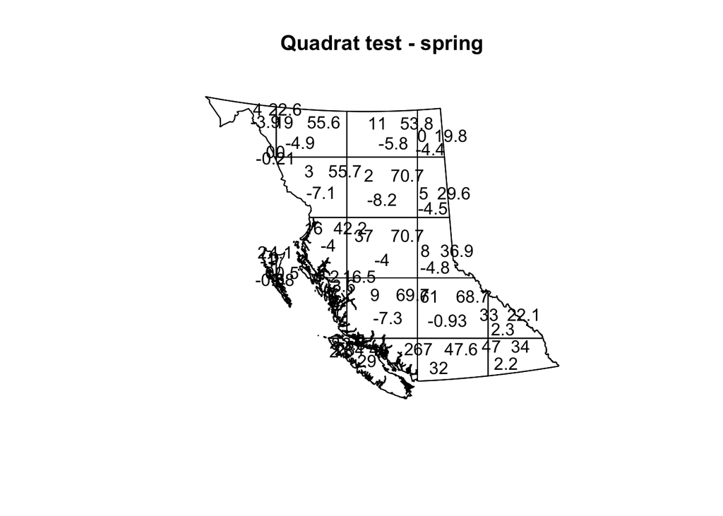

```
##
##  Chi-squared test of CSR using quadrat counts
##
## data:  ppp_list[[s]]
## X2 = 3767, df = 20, p-value < 2.2e-16
## alternative hypothesis: two.sided
##
## Quadrats: 21 tiles (irregular windows)
```

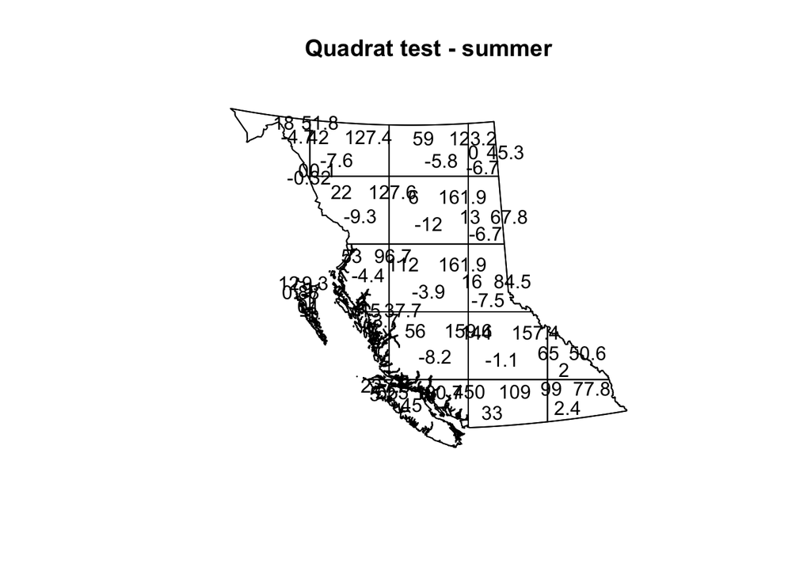

```
##
##  Chi-squared test of CSR using quadrat counts
##
## data:  ppp_list[[s]]
## X2 = 2720.5, df = 20, p-value < 2.2e-16
## alternative hypothesis: two.sided
##
## Quadrats: 21 tiles (irregular windows)
```

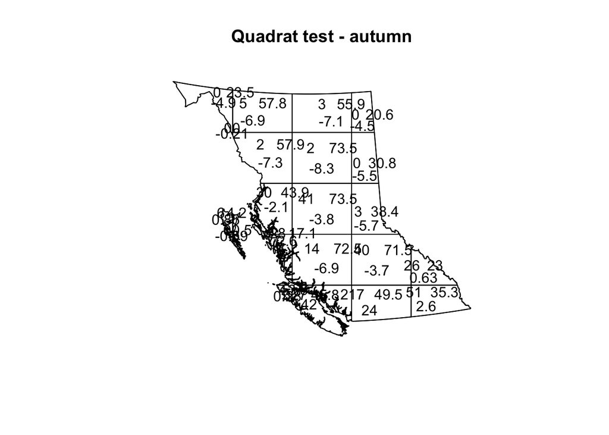

```r
# quadrat tests
for (s in names(ppp_list)) {
  qt <- quadrat.test(ppp_list[[s]], nx = 5, ny = 5)
  print(qt)
  plot(qt, main = paste("Quadrat test -", s))
}
```

Based on the results of the quadrat test, bear locations do not follow a random distribution and show spatial clustering across all seasons, meaning their presence is likely influenced by specific environmental or ecological factors that are season-dependent. The quadrat test results suggest that for all seasons (winter, spring, summer, and autumn), bear locations exhibit significant spatial clustering or non-random patterns rather than being randomly distributed (as indicated by the very small p-values).